# use case - decathlon

### Ce notebook se présente en trois parties

### Partie 1 : Exploration préliminaire des données

### Partie 2 : Réponses aux questions préliminaires

### Partie 3 : Modélisation

# Partie 1

## 1.a Chargement des données et exploration préliminaire

```python
#les fichiers parquets ont été convertis en csv au préalable pour des raisons
#de conflit de dépendance locales
```

```python
import pandas as pd

train_xlsx_path = 'train.xlsx'
test_csv_path = 'test.csv'
bu_feat_csv_path = 'bu_feat.csv'

# convertir les fichiers en dataframe
train_df = pd.read_excel(train_xlsx_path)
test_df = pd.read_csv(test_csv_path)
bu_feat_df = pd.read_csv(bu_feat_csv_path)
```

```python
# Afficher les informations des dataframes
print("Train dataFrame:")
train_df.info()
train_df.head()
```

```
Train DataFrame:
<class 'pandas.core.frame.DataFrame'>
RangeIndex: 277719 entries, 0 to 277718
Data columns (total 4 columns):
 #   Column                 Non-Null Count   Dtype
---  ------                 --------------   -----
 0   day_id                 277719 non-null  datetime64[ns]
 1   but_num_business_unit  277719 non-null  int64
 2   dpt_num_department     277719 non-null  int64
 3   turnover               277719 non-null  float64
dtypes: datetime64[ns](1), float64(1), int64(2)
memory usage: 8.5 MB
```

|  | day_id | but_num_business_unit | dpt_num_department | turnover |
| --- | --- | --- | --- | --- |
| 0 | 2017-09-30 | 64 | 127 | 580.308443 |
| 1 | 2017-09-30 | 119 | 127 | 1512.995918 |
| 2 | 2017-09-30 | 4 | 88 | 668.593556 |
| 3 | 2017-09-30 | 425 | 127 | 0.000000 |
| 4 | 2017-09-30 | 513 | 73 | 0.000000 |

```python
print("\nTest dataFrame:")
test_df.info()
test_df.head()
```

```
Test DataFrame:
<class 'pandas.core.frame.DataFrame'>
RangeIndex: 10136 entries, 0 to 10135
Data columns (total 3 columns):
 #   Column                 Non-Null Count  Dtype
---  ------                 --------------  -----
 0   day_id                 10136 non-null  object
 1   but_num_business_unit  10136 non-null  int64
 2   dpt_num_department     10136 non-null  int64
dtypes: int64(2), object(1)
memory usage: 237.7+ KB
```

|  | day_id | but_num_business_unit | dpt_num_department |
| --- | --- | --- | --- |
| 0 | 2017-11-25 | 95 | 73 |
| 1 | 2017-11-25 | 4 | 117 |
| 2 | 2017-11-25 | 113 | 127 |
| 3 | 2017-11-25 | 93 | 117 |
| 4 | 2017-11-25 | 66 | 127 |

```python
print("\nBU dataFrame:")
bu_feat_df.info()
bu_feat_df.head()
```

[output not shown]

|  | but_num_business_unit | but_postcode | but_latitude | but_longitude | but_region_idr_region | zod_idr_zone_dgr |
| --- | --- | --- | --- | --- | --- | --- |
| 0 | 1609 | 80100 | 50.096306 | 1.867220 | 69 | 4 |
| 1 | 1995 | 95700 | 48.991087 | 2.520903 | 3 | 6 |
| 2 | 1800 | 73210 | 45.552933 | 6.644736 | 51 | 4 |
| 3 | 238 | 47550 | 44.175370 | 0.638869 | 134 | 10 |
| 4 | 201 | 13546 | 43.508418 | 5.406423 | 71 | 10 |

### Les datasets n'ont pas de données manquantes,

### les formats de données sont correctes,

### a part pour la colonne day-id, qui doit etre convertie en datetime et mise en index

## 1.b Exploration et visualisations préliminaires

```python
# Nombre total de départements et de business units
nb_departements = train_df['dpt_num_department'].nunique()
nb_business_units = train_df['but_num_business_unit'].nunique()

print(f"Nombre total de départements : {nb_departements}")
print(f"Nombre total de business units : {nb_business_units}")
```

```
Nombre total de départements : 4
Nombre total de business units : 322
```

```python
# Nombre de business units par département
bu_par_departement = train_df.groupby('dpt_num_department')['but_num_business_unit'].nunique()

print("Nombre de business units par département :")
print(bu_par_departement)
```

```
Nombre de business units par département :
dpt_num_department
73     316
88     321
117    314
127    317
Name: but_num_business_unit, dtype: int64
```

```python
# Joindre les datasets `train_df` et `bu_feat` pour obtenir des informations géographiques
train_bu = train_df.merge(bu_feat_df, on='but_num_business_unit', how='left')
```

```
   dpt_num_department  num_regions
0                  73           29
1                  88           29
2                 117           29
3                 127           29
```

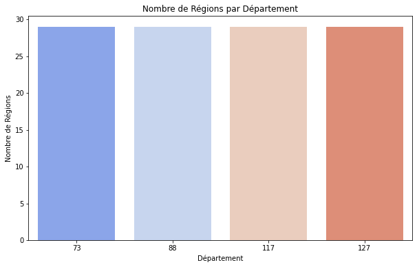

```python
# Compter le nombre de régions dans chaque département
regions_per_department = train_bu.groupby('dpt_num_department')['but_region_idr_region'].nunique().reset_index()
regions_per_department.columns = ['dpt_num_department', 'num_regions']

# Afficher le nombre de régions par département
print(regions_per_department)

# Visualisation avec un diagramme à barres
import matplotlib.pyplot as plt
import seaborn as sns

plt.figure(figsize=(10,6))
sns.barplot(x='dpt_num_department', y='num_regions', data=regions_per_department, palette='coolwarm')
plt.title("Nombre de Régions par Département")
plt.xlabel("Département")
plt.ylabel("Nombre de Régions")
plt.show()
```

```python
import folium
from folium.plugins import MarkerCluster

# Créer une carte centrée sur une latitude et longitude moyenne
latitude_mean = train_bu['but_latitude'].mean()
longitude_mean = train_bu['but_longitude'].mean()
mymap = folium.Map(location=[latitude_mean, longitude_mean], zoom_start=6)

# Ajouter un cluster de markers pour visualiser les régions
marker_cluster = MarkerCluster().add_to(mymap)

# Boucler sur les lignes de `bu_feat` pour ajouter chaque BU sur la carte
for idx, row in train_bu.iterrows():
    popup_text = f"BU: {row['but_num_business_unit']}, Département: {row['dpt_num_department']}, Région: {row['but_region_idr_region']}"
    folium.Marker(
        location=[row['but_latitude'], row['but_longitude']],
        popup=popup_text,
        icon=folium.Icon(color="blue", icon="info-sign")
    ).add_to(marker_cluster)

# Afficher la carte
mymap.save("regions_map.html")
mymap
```

Les résultats montrent que les départements contiennent plusieurs BU et plusieurs régions, qui sont repartis de manière équilibrée. Cela suggère que chaque département gère un nombre similaire de business units et de régions, ce qui peut être utile pour analyser les tendances et les performances par département.

### Nous allons crééer de nouvelles features de temps, qui pourront servir plus tard

```python
# Conversion de 'day_id' en type datetime
train_df['day_id'] = pd.to_datetime(train_df['day_id'])
test_df['day_id'] = pd.to_datetime(test_df['day_id'])
```

```python
def create_features(df):
    df['week'] = df['day_id'].dt.isocalendar().week
    df['month'] = df['day_id'].dt.month
    df['day_of_week'] = df['day_id'].dt.dayofweek
    df['year'] = df['day_id'].dt.year
    return df
```

```python
train_df= create_features(train_df)
test_df = create_features(test_df)
```

```python
test_df
```

|  | day_id | but_num_business_unit | dpt_num_department | week | month | day_of_week | year |
| --- | --- | --- | --- | --- | --- | --- | --- |
| 0 | 2017-11-25 | 95 | 73 | 47 | 11 | 5 | 2017 |
| 1 | 2017-11-25 | 4 | 117 | 47 | 11 | 5 | 2017 |
| 2 | 2017-11-25 | 113 | 127 | 47 | 11 | 5 | 2017 |
| 3 | 2017-11-25 | 93 | 117 | 47 | 11 | 5 | 2017 |
| 4 | 2017-11-25 | 66 | 127 | 47 | 11 | 5 | 2017 |
| ... | ... | ... | ... | ... | ... | ... | ... |
| 10131 | 2017-10-07 | 61 | 88 | 40 | 10 | 5 | 2017 |
| 10132 | 2017-10-07 | 641 | 117 | 40 | 10 | 5 | 2017 |
| 10133 | 2017-10-07 | 724 | 117 | 40 | 10 | 5 | 2017 |
| 10134 | 2017-10-07 | 1302 | 117 | 40 | 10 | 5 | 2017 |
| 10135 | 2017-10-07 | 1126 | 88 | 40 | 10 | 5 | 2017 |

10136 rows × 7 columns

```python
# Définir 'day_id' comme index
train_df.set_index('day_id', inplace=True)
test_df.set_index('day_id', inplace=True)
```

```python
test_df.head()
```

| day_id | but_num_business_unit | dpt_num_department | week | month | day_of_week | year |
| --- | --- | --- | --- | --- | --- | --- |
| 2017-11-25 | 95 | 73 | 47 | 11 | 5 | 2017 |
| 2017-11-25 | 4 | 117 | 47 | 11 | 5 | 2017 |
| 2017-11-25 | 113 | 127 | 47 | 11 | 5 | 2017 |
| 2017-11-25 | 93 | 117 | 47 | 11 | 5 | 2017 |
| 2017-11-25 | 66 | 127 | 47 | 11 | 5 | 2017 |

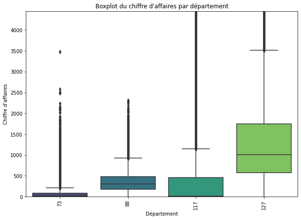

```python
#Boxplot du chiffre d'affaire par departement
import matplotlib.pyplot as plt
import seaborn as sns

plt.figure(figsize=(10, 7))
sns.boxplot(data=train_df, x='dpt_num_department', y='turnover', palette="viridis")
plt.title('Boxplot du chiffre d\'affaires par département')
plt.xlabel('Département')
plt.ylabel('Chiffre d\'affaires')
plt.xticks(rotation=90)
plt.ylim(0, train_df['turnover'].quantile(0.99))  # Limiter l'axe des y pour éviter les valeurs extrêmes
plt.show()
```

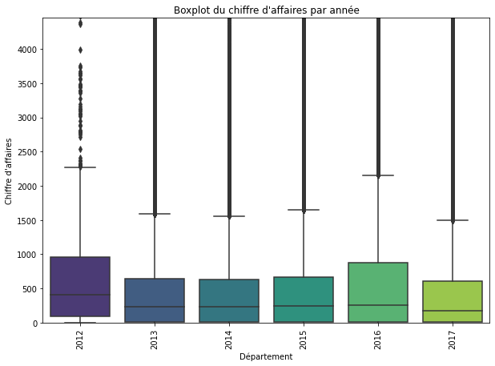

```python
#Boxplot du chiffre d'affaire par année
import matplotlib.pyplot as plt
import seaborn as sns

plt.figure(figsize=(10, 7))
sns.boxplot(data=train_df, x='year', y='turnover', palette="viridis")
plt.title('Boxplot du chiffre d\'affaires par année')
plt.xlabel('Département')
plt.ylabel('Chiffre d\'affaires')
plt.xticks(rotation=90)
plt.ylim(0, train_df['turnover'].quantile(0.99))  # Limiter l'axe des y pour éviter les valeurs extrêmes
plt.show()
```

### les deux graphiques nous montrent que le departement avec le plus grand chiffre

### d'affaire au fil des années

### est le 127, et que le jeu de données comporte beaucoup d'outliers.

### Ces outliers peuvent représenter des comportements exceptionnels,

### qui sont le résultat d'évenements comme des campagnes promotionnelles

### Mais il est fort possible que cela soit du au réechentillonnage des donnée

### Afin de les traiter, nous pourrions les remplacer par la médiane

### ou utiliser d'autres techniques comme une transformation logarithmique

# Partie 2

## 2. Questions préliminaires

### 2.a Quel departement a le plus grand chiffre d'affaire en 2016 ?

```python
# Filtrer pour l'année 2016
df_2016 = train_df[train_df['year'] == 2016]

# Trouver le département avec le plus grand chiffre d'affaires
top_department_2016 = df_2016.groupby('dpt_num_department')['turnover'].sum().idxmax() #retourne l'index de la val max
print(f"Département avec le chiffre d'affaires le plus élevé en 2016 : {top_department_2016}")
```

```
Département avec le chiffre d'affaires le plus élevé en 2016 : 127
```

### 2.b Top 5 semaines pour le département 88 en 2015

```
Top 5 semaines pour le département 88 en 2015:
week
27    141679.864768
37    139674.400588
36    137825.642436
38    137232.460861
28    125835.541415
Name: turnover, dtype: float64
```

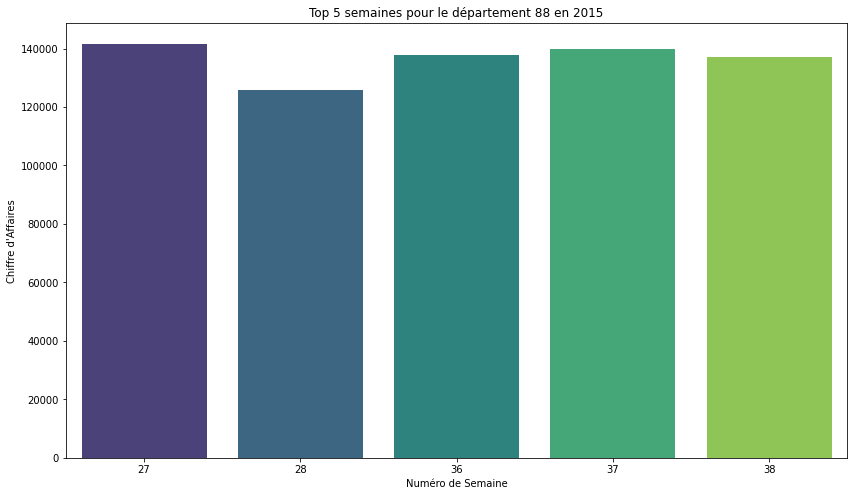

```python
# Filtrer les données pour 2015 et le département 88
train_2015_dept_88 = train_df[(train_df['year'] == 2015) & (train_df['dpt_num_department'] == 88)]


# Trouver les 5 meilleures semaines en termes de chiffre d'affaires
top_weeks_88 = train_2015_dept_88.groupby('week')['turnover'].sum().nlargest(5)

print("Top 5 semaines pour le département 88 en 2015:")
print(top_weeks_88)

# Visualisation
plt.figure(figsize=(14, 8))
sns.barplot(x=top_weeks_88.index, y=top_weeks_88.values, palette="viridis")
plt.title('Top 5 semaines pour le département 88 en 2015')
plt.xlabel('Numéro de Semaine')
plt.ylabel('Chiffre d\'Affaires')
plt.show()
```

### 2.c Magasin avec le chiffre d'affaires le plus élevé en 2014

```python
#on peut utiliser le dataframe créé précedemment (train_bu) pour avoir plus d'informations
#Filtrer sur l'année 2014
df_2014 = train_bu[(train_bu['year']== 2014)]

# Trouver le département avec le plus grand chiffre d'affaires
top_bu_2014 = df_2014.groupby('but_num_business_unit')['turnover'].sum().idxmax() #retourne l'index de la val max
top_depart_2014 = df_2014.groupby('dpt_num_department')['turnover'].sum().idxmax() #retourne l'index de la val max
top_code_2014 = df_2014.groupby('but_postcode')['turnover'].sum().idxmax() #retourne l'index de la val max

print(f"Le magasin avec le chiffre d'affaires le plus élevé en 2014 est le magasin numéro {top_bu_2014}, du departement {top_depart_2014} situé à {top_code_2014}.")
```

```
Le magasin avec le chiffre d'affaires le plus élevé en 2014 est le magasin numéro 121, du departement 127 situé à 69500.
```

## Cela confirme ce qu'on a pu voir sur les graphiques précedents

## le departement avec le plus grand CA est le 127

### 2.d departement 73

[figure not shown]

```python
import matplotlib.pyplot as plt

#On filtre les données pour le derpartement 73 sur les deux dernieres années, pour mieux visualiser le CA
data_73_last_2_years = train_df[(train_df['dpt_num_department'] == 73) & (train_df['year'] >= 2015)]

# Plot turnover
plt.figure(figsize=(12, 6))
plt.plot(data_73_last_2_years.index, data_73_last_2_years['turnover'], label='Turnover')

plt.title('Turnover pour le department 73 (2016-2017)')
plt.xlabel('Date')
plt.ylabel('Turnover')
plt.xticks(rotation=45)
plt.grid(True)
plt.show()
```

### On observe des pics en periode estivale, ce departement doit representer les sports

### d'été (natation, surf, plongée, etc)

### 2.e departement 117

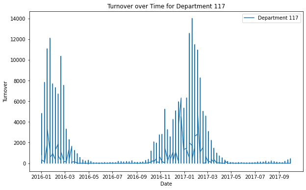

```python
import matplotlib.pyplot as plt


# Filtrer le departement 117
data_117_last_2_years = train_df[(train_df['dpt_num_department'] == 117) & (train_df['year'] >= 2016)]

# Plot turnover
plt.figure(figsize=(10,6))
plt.plot(data_117_last_2_years.index, data_117_last_2_years['turnover'], label='Department 117')
plt.xlabel('Date')
plt.ylabel('Turnover')
plt.legend()
plt.title('Turnover over Time for Department 117')
plt.show()
```

### 2.f Les series temporelles sont elles stationnaires ?

```python
from statsmodels.tsa.stattools import adfuller

# Fonction pour tester la stationnarité
def test_stationarity(timeseries):
    result = adfuller(timeseries, autolag='AIC')
    print('ADF Statistic:', result[0])
    print('p-value:', result[1])
    print('Critical Values:', result[4])
    if result[1] <= 0.05:
        print("La série est stationnaire")
    else:
        print("La série n'est pas stationnaire")

# Test de stationnarité pour le chiffre d'affaire
test_stationarity(train_df['turnover'])
```

```
ADF Statistic: -39.00596779414079
p-value: 0.0
Critical Values: {'1%': -3.4303735542285154, '5%': -2.8615504106733822, '10%': -2.5667755412243554}
La série est stationnaire
```

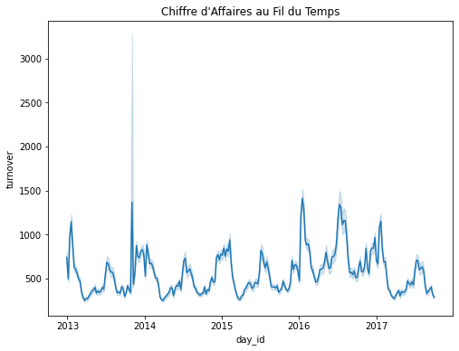

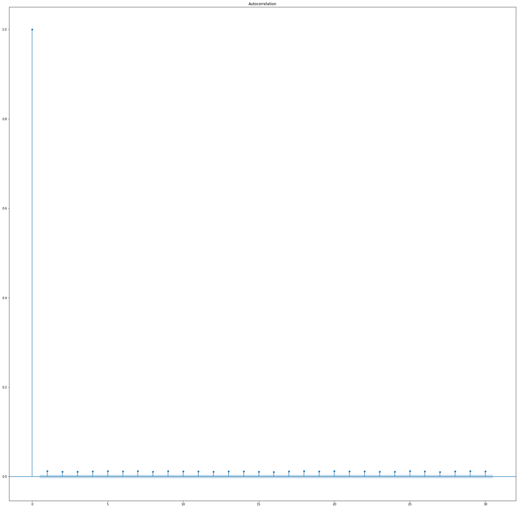

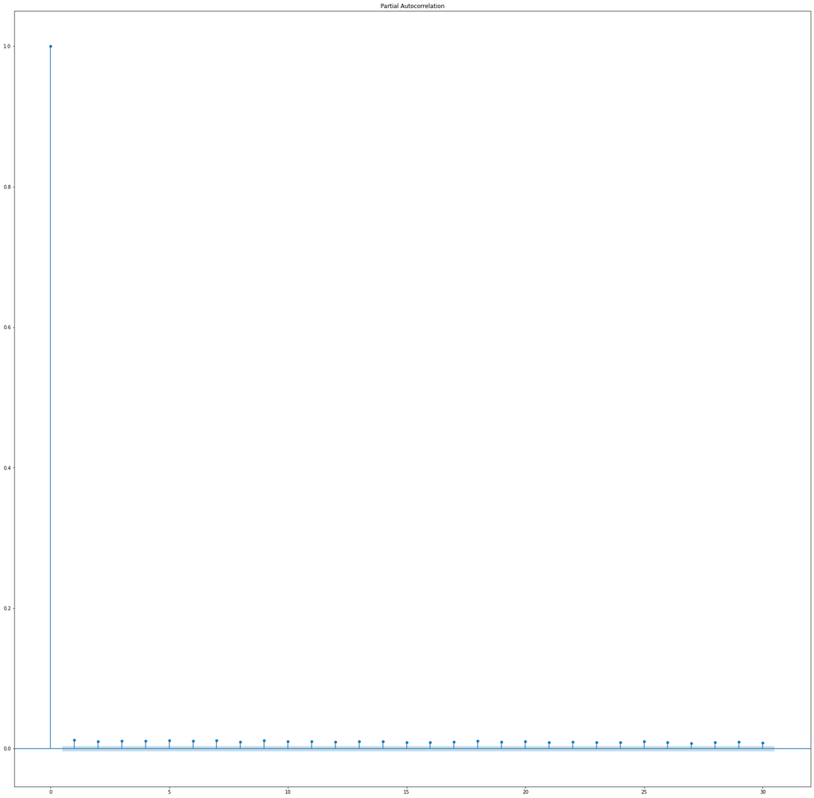

```python
import matplotlib.pyplot as plt
import seaborn as sns
from statsmodels.graphics.tsaplots import plot_acf, plot_pacf

# Visualisation de la série
plt.figure(figsize=(8, 6))
sns.lineplot(data=train_df['turnover'])
plt.title("Chiffre d'Affaires au Fil du Temps")
plt.show()

# Graphiques ACF et PACF
plot_acf(train_df['turnover'], lags=30)
plt.show()

plot_pacf(train_df['turnover'], lags=30)
plt.show()
```

### Au vu du resultat du test de Dickey Fuller et des plots ACF / PACF, on peut deduire

### que la serie est stationnaire

### Il est important que la série soit stationnaire, car les modèles de ML ne peuvent

### traiter les données non stationnaires.

## 2.g La serie peut elle etre decomposée en plusieurs composantes ?

#### visualisation pour les données du dataset

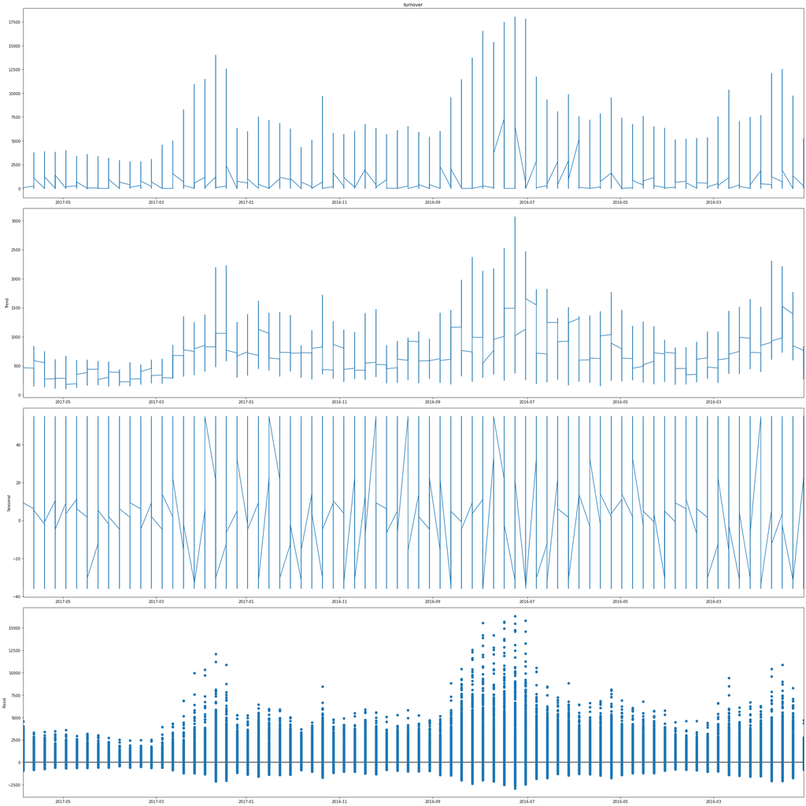

```python
from statsmodels.tsa.seasonal import seasonal_decompose

plt.rcParams.update({'figure.figsize':(30,30)})
def add_decomposition (x) :
    result_decom = seasonal_decompose (x, model ='additive', period=30)
    result_decom.plot()
    plt.show()

#on applique la decomposition à une partie du dataset afin d'avoir une vision plus claire
add_decomposition(train_df['turnover'].loc['2016-01-01':'2017-06-01'])
```

#### Visualisation par departement

```
Decomposition pour le department: 73
```

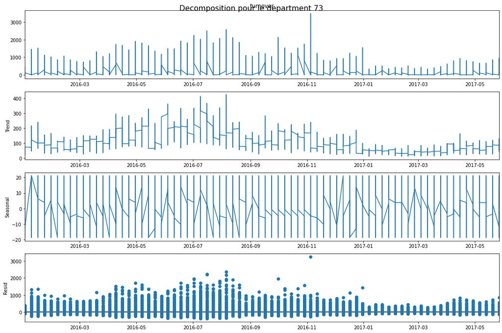

```
Decomposition pour le department: 88
```

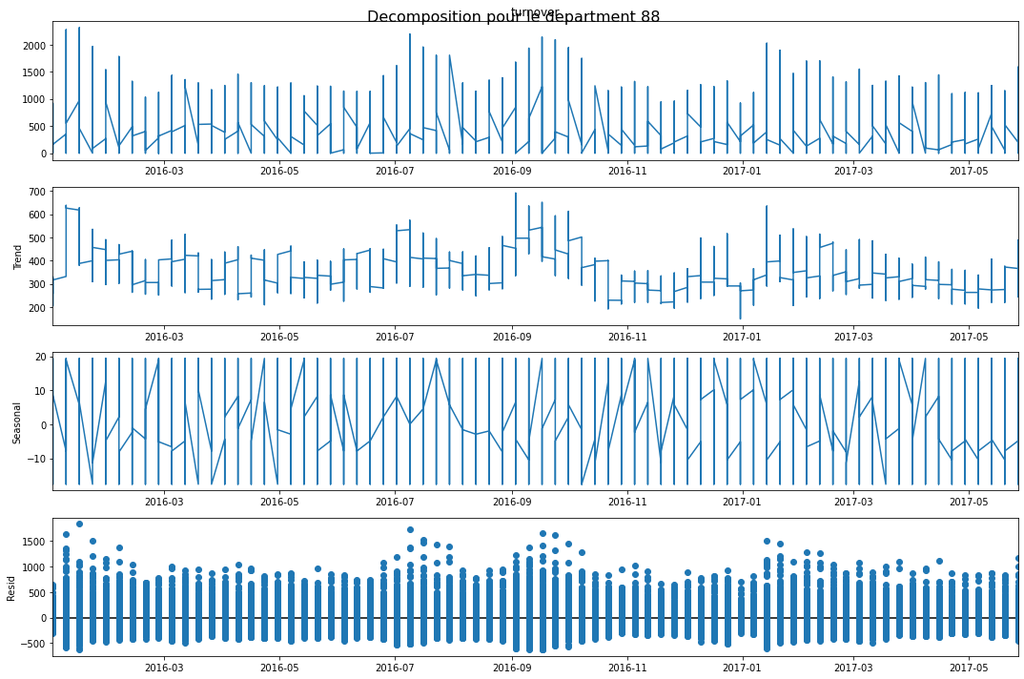

```
Decomposition pour le department: 117
```

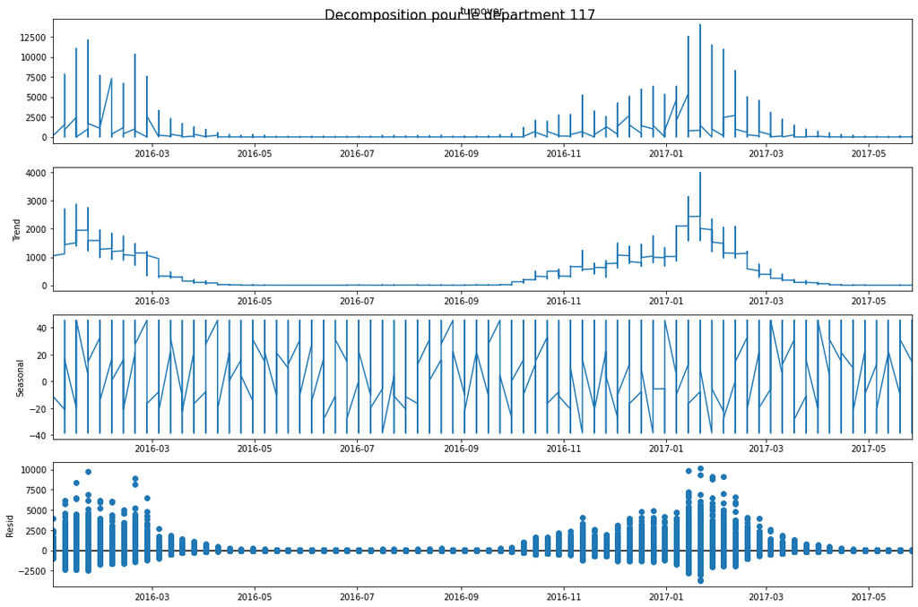

```
Decomposition pour le department: 127
```

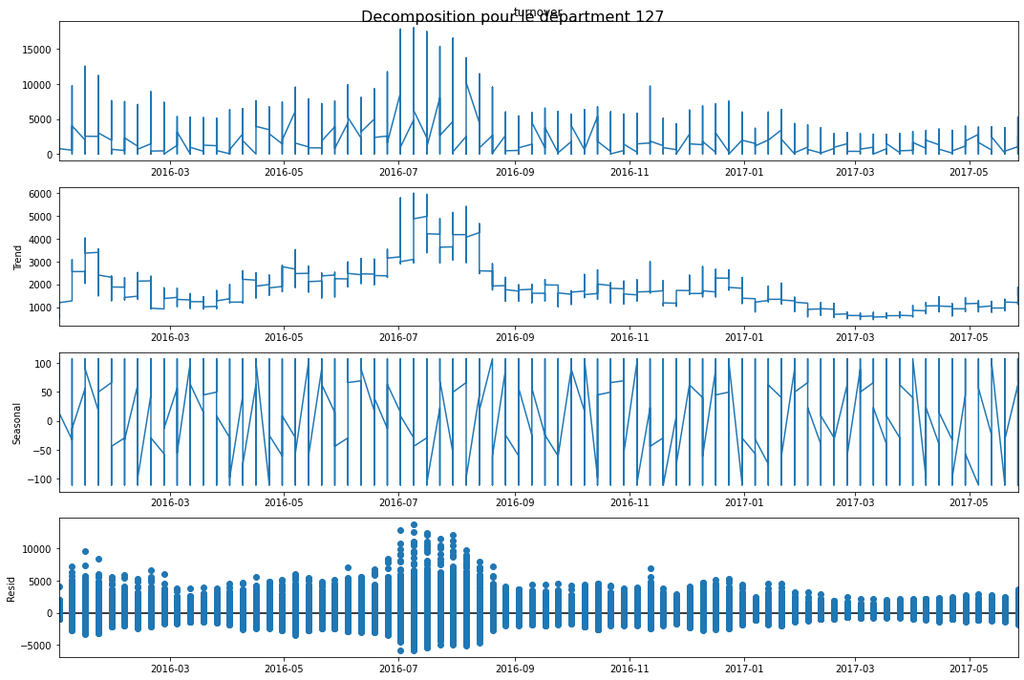

```python
from statsmodels.tsa.seasonal import seasonal_decompose
import matplotlib.pyplot as plt

plt.rcParams.update({'figure.figsize':(15,10)})

def add_decomposition_by_department(df, start_date, end_date):

    # visualiser les composantes sur une période spécifique
    df_filtered = df.loc[start_date:end_date]

    # Application de la décomposition pour chaque département
    for dept, group in df_filtered.groupby('dpt_num_department'):
        print(f"Decomposition pour le department: {dept}")

        result_decom = seasonal_decompose(group['turnover'], model='additive', period=30)
        result_decom.plot()
        plt.suptitle(f'Decomposition pour le department {dept}', fontsize=16)
        plt.show()


# Example usage: Apply decomposition to a specific date range for each department
add_decomposition_by_department(train_df, '2016-01-01', '2017-06-01')
```

#### Oui la serie peut etre décomposée en ses composantes principales qui sont :

#### -La tendance : Represente l'evolution generale des données, elle peut etre à la hausse ou à la baisse

#### -La saisonnalité : Represente la variation réguliere dans les données, qui se répete à intervalles fixes

#### -Les résidus : Ils capturent l'irrégularité imprévisibles des données

### On peut remarquer que chaque département a ses spécificités

### d'ou la necessite de faire un forecast par departement

# Partie 3

## 3. Modeling

### 3.a Estimateur simple pour predire le turnover sur les 8 prochaines semaines, et evaluation du modèle

#### A noter que pour permettre l'evaluation du modele, nous avons splitter le dataset

#### train en deux parties (train et test) afin d'evaluer le modele sur le forecast des

#### deux derniers mois, car le test.parquet ne contenait aucune donnée de turnover et

#### cela ne permettait donc pas d'evaluer le modèle

```python
from statsmodels.tsa.arima.model import ARIMA
from datetime import timedelta
from sklearn.metrics import mean_absolute_error, mean_squared_error

# cette fonction permet de filtrer les données par departement et bu
def preprocess_data(df, business_unit, department):
    df_filtered = df[(df['but_num_business_unit'] == business_unit) &
                     (df['dpt_num_department'] == department)]
    df_filtered = df_filtered.resample('D').sum().fillna(0)
    return df_filtered

# Fonction de definition du modèle
def fit_arima_model(df_filtered):
    model = ARIMA(df_filtered['turnover'], order=(5, 1, 0))
    model_fit = model.fit()
    return model_fit

# Split chronologique du train dataset
# On prend l'historique des dernieres année pour le train set
# On garde les deux derniers mois pour le test (basé sur la derniere date du train)
def split_data(df, last_n_months=2):
    last_date = df.index.max()
    cutoff_date = last_date - pd.DateOffset(months=last_n_months)
    train = df.loc[:cutoff_date]
    test = df.loc[cutoff_date + timedelta(days=1):]
    return train, test

# Function pour entrainer le modèle et calculer les metriques d'evaluation
def forecast_turnover(df, business_unit, department, forecast_days=56):
    # application du filtre en fct des attributs choisis
    df_filtered = preprocess_data(df, business_unit, department)

    # Split data into training and test sets (last 2 months as test)
    train_df, test_df = split_data(df_filtered)

    # Fit ARIMA model on training set
    model_fit = fit_arima_model(train_df)

    # Forecast sur le mm nbre de jour du test set
    forecast = model_fit.forecast(steps=len(test_df))

    # Creation d'un DataFrame pr les forecast du modèle vs valeurs réelles
    forecast_df = pd.DataFrame({
        'day_id': test_df.index,
        'but_num_business_unit': business_unit,
        'dpt_num_department': department,
        'forecast': forecast,
        'actual_turnover': test_df['turnover'].values
    })
    forecast_df.set_index('day_id', inplace=True)

    # Calcul des métriques d'evaluation
    mae = mean_absolute_error(forecast_df['actual_turnover'], forecast_df['forecast'])
    mse = mean_squared_error(forecast_df['actual_turnover'], forecast_df['forecast'])
    rmse = mse ** 0.5  # Root Mean Squared Error
    mape = (abs(forecast_df['actual_turnover'] - forecast_df['forecast']) / forecast_df['actual_turnover']).mean() * 100

    # Print metrics
    print(f"Mean Absolute Error (MAE): {mae}")
    print(f"Mean Squared Error (MSE): {mse}")
    print(f"Root Mean Squared Error (RMSE): {rmse}")

    return forecast_df

# Exemple
business_unit = 64
department = 127

# Forecast + evaluation
forecast_arima_df = forecast_turnover(data, business_unit, department)
```

```
Mean Absolute Error (MAE): 406.0774773381588
Mean Squared Error (MSE): 325953.0887629422
Root Mean Squared Error (RMSE): 570.9230147427429
```